# Project1

Tycho Gormley

2024-10-06

## Background

A significant number of hotel bookings are called off due to cancellations or no-shows. The typical reasons for cancellations include change of plans, scheduling conflicts, etc. This is often made easier by the option to do so free of charge or preferably at a low cost which is beneficial to hotel guests but it is a less desirable and possibly revenue-diminishing factor for hotels to deal with. Such losses are particularly high on last-minute cancellations.

The new technologies involving online booking channels have dramatically changed customers’ booking possibilities and behavior. This adds a further dimension to the challenge of how hotels handle cancellations, which are no longer limited to traditional booking and guest characteristics.

The cancellation of bookings impact a hotel on various fronts: 1. Loss of resources (revenue) when the hotel cannot resell the room. 2. Additional costs of distribution channels by increasing commissions or paying for publicity to help sell these rooms. 3. Lowering prices last minute, so the hotel can resell a room, resulting in reducing the profit margin. 4. Human resources to make arrangements for the guests.

## Data Description

The data contains the different attributes of customers’ booking details. The detailed data dictionary is given below.

**Data Dictionary**

- Booking_ID: unique identifier of each booking
- no_of_adults: Number of adults
- no_of_children: Number of Children
- no_of_weekend_nights: Number of weekend nights (Saturday or Sunday) the guest stayed or booked to stay at the hotel
- no_of_week_nights: Number of week nights (Monday to Friday) the guest stayed or booked to stay at the hotel
- type_of_meal_plan: Type of meal plan booked by the customer:
  - Not Selected – No meal plan selected
  - Meal Plan 1 – Breakfast
  - Meal Plan 2 – Half board (breakfast and one other meal)
  - Meal Plan 3 – Full board (breakfast, lunch, and dinner)
- required_car_parking_space: Does the customer require a car parking space? (0 - No, 1- Yes)
- room_type_reserved: Type of room reserved by the customer. The values are ciphered (encoded) by INN Hotels.
- lead_time: Number of days between the date of booking and the arrival date
- arrival_year: Year of arrival date
- arrival_month: Month of arrival date
- arrival_date: Date of the month
- market_segment_type: Market segment designation.
- repeated_guest: Is the customer a repeated guest? (0 - No, 1- Yes)
- no_of_previous_cancellations: Number of previous bookings that were canceled by the customer prior to the current booking
- no_of_previous_bookings_not_canceled: Number of previous bookings not canceled by the customer prior to the current booking
- avg_price_per_room: Average price per day of the reservation; prices of the rooms are dynamic. (in euros)
- no_of_special_requests: Total number of special requests made by the customer (e.g. high floor, view from the room, etc)
- booking_status: Flag indicating if the booking was canceled or not.

### Loading Data

```r
hotel <- read.csv("INNHotelsGroup.csv")
# copying data to another variable to avoid any changes to original data
data <- hotel
```

```r
print(class(data))
```

```
## [1] "data.frame"
```

```r
str(data)
```

```
## 'data.frame':    36275 obs. of  19 variables:
##  $ Booking_ID                          : chr  "INN00001" "INN00002" "INN00003" "INN00004" ...
##  $ no_of_adults                        : int  2 2 1 2 2 2 2 2 3 2 ...
##  $ no_of_children                      : int  0 0 0 0 0 0 0 0 0 0 ...
##  $ no_of_weekend_nights                : int  1 2 2 0 1 0 1 1 0 0 ...
##  $ no_of_week_nights                   : int  2 3 1 2 1 2 3 3 4 5 ...
##  $ type_of_meal_plan                   : chr  "Meal Plan 1" "Not Selected" "Meal Plan 1" "Meal Plan 1" ...
##  $ required_car_parking_space          : int  0 0 0 0 0 0 0 0 0 0 ...
##  $ room_type_reserved                  : chr  "Room_Type 1" "Room_Type 1" "Room_Type 1" "Room_Type 1" ...
##  $ lead_time                           : int  224 5 1 211 48 346 34 83 121 44 ...
##  $ arrival_year                        : int  2017 2018 2018 2018 2018 2018 2017 2018 2018 2018 ...
##  $ arrival_month                       : int  10 11 2 5 4 9 10 12 7 10 ...
##  $ arrival_date                        : int  2 6 28 20 11 13 15 26 6 18 ...
##  $ market_segment_type                 : chr  "Offline" "Online" "Online" "Online" ...
##  $ repeated_guest                      : int  0 0 0 0 0 0 0 0 0 0 ...
##  $ no_of_previous_cancellations        : int  0 0 0 0 0 0 0 0 0 0 ...
##  $ no_of_previous_bookings_not_canceled: int  0 0 0 0 0 0 0 0 0 0 ...
##  $ avg_price_per_room                  : num  65 106.7 60 100 94.5 ...
##  $ no_of_special_requests              : int  0 1 0 0 0 1 1 1 1 3 ...
##  $ booking_status                      : chr  "Not_Canceled" "Not_Canceled" "Canceled" "Canceled" ...
```

```r
head(data)
```

```
##   Booking_ID no_of_adults no_of_children no_of_weekend_nights no_of_week_nights
## 1   INN00001            2              0                    1                 2
## 2   INN00002            2              0                    2                 3
## 3   INN00003            1              0                    2                 1
## 4   INN00004            2              0                    0                 2
## 5   INN00005            2              0                    1                 1
## 6   INN00006            2              0                    0                 2
##   type_of_meal_plan required_car_parking_space room_type_reserved lead_time
## 1       Meal Plan 1                          0        Room_Type 1       224
## 2      Not Selected                          0        Room_Type 1         5
## 3       Meal Plan 1                          0        Room_Type 1         1
## 4       Meal Plan 1                          0        Room_Type 1       211
## 5      Not Selected                          0        Room_Type 1        48
## 6       Meal Plan 2                          0        Room_Type 1       346
##   arrival_year arrival_month arrival_date market_segment_type repeated_guest
```

[output cut: 20 more lines]

```r
tail(data)
```

```
##       Booking_ID no_of_adults no_of_children no_of_weekend_nights
## 36270   INN36270            2              2                    0
## 36271   INN36271            3              0                    2
## 36272   INN36272            2              0                    1
## 36273   INN36273            2              0                    2
## 36274   INN36274            2              0                    0
## 36275   INN36275            2              0                    1
##       no_of_week_nights type_of_meal_plan required_car_parking_space
## 36270                 1       Meal Plan 1                          0
## 36271                 6       Meal Plan 1                          0
## 36272                 3       Meal Plan 1                          0
## 36273                 6       Meal Plan 1                          0
## 36274                 3      Not Selected                          0
## 36275                 2       Meal Plan 1                          0
##       room_type_reserved lead_time arrival_year arrival_month arrival_date
```

[output cut: 27 more lines]

### Cleaning

We can see that all of the entries in the Booking_ID column are unique. Hence, this column would not add any value to our analysis. Let’s drop this column.

```r
data <- data[ , !(names(data) %in% c("Booking_ID"))]
head(data)
```

```
##   no_of_adults no_of_children no_of_weekend_nights no_of_week_nights
## 1            2              0                    1                 2
## 2            2              0                    2                 3
## 3            1              0                    2                 1
## 4            2              0                    0                 2
## 5            2              0                    1                 1
## 6            2              0                    0                 2
##   type_of_meal_plan required_car_parking_space room_type_reserved lead_time
## 1       Meal Plan 1                          0        Room_Type 1       224
## 2      Not Selected                          0        Room_Type 1         5
## 3       Meal Plan 1                          0        Room_Type 1         1
## 4       Meal Plan 1                          0        Room_Type 1       211
## 5      Not Selected                          0        Room_Type 1        48
## 6       Meal Plan 2                          0        Room_Type 1       346
##   arrival_year arrival_month arrival_date market_segment_type repeated_guest
```

[output cut: 20 more lines]

## Check for missing values

```r
print(sum(is.na(data)))
```

```
## [1] 0
```

## Summary Statistics for Numerical Columns

```r
num_cols <- sapply(data, is.numeric)
print(summary(data[ , num_cols]))
```

```
##   no_of_adults  no_of_children  no_of_weekend_nights no_of_week_nights
##  Min.   :0.00   Min.   : 0.00   Min.   :0.00         Min.   : 0.0
##  1st Qu.:2.00   1st Qu.: 0.00   1st Qu.:0.00         1st Qu.: 1.0
##  Median :2.00   Median : 0.00   Median :1.00         Median : 2.0
##  Mean   :1.84   Mean   : 0.11   Mean   :0.81         Mean   : 2.2
##  3rd Qu.:2.00   3rd Qu.: 0.00   3rd Qu.:2.00         3rd Qu.: 3.0
##  Max.   :4.00   Max.   :10.00   Max.   :7.00         Max.   :17.0
##  required_car_parking_space   lead_time    arrival_year  arrival_month
##  Min.   :0.000              Min.   :  0   Min.   :2017   Min.   : 1.00
##  1st Qu.:0.000              1st Qu.: 17   1st Qu.:2018   1st Qu.: 5.00
##  Median :0.000              Median : 57   Median :2018   Median : 8.00
##  Mean   :0.031              Mean   : 85   Mean   :2018   Mean   : 7.42
##  3rd Qu.:0.000              3rd Qu.:126   3rd Qu.:2018   3rd Qu.:10.00
##  Max.   :1.000              Max.   :443   Max.   :2018   Max.   :12.00
##   arrival_date  repeated_guest  no_of_previous_cancellations
##  Min.   : 1.0   Min.   :0.000   Min.   : 0.00
##  1st Qu.: 8.0   1st Qu.:0.000   1st Qu.: 0.00
##  Median :16.0   Median :0.000   Median : 0.00
##  Mean   :15.6   Mean   :0.026   Mean   : 0.02
##  3rd Qu.:23.0   3rd Qu.:0.000   3rd Qu.: 0.00
##  Max.   :31.0   Max.   :1.000   Max.   :13.00
##  no_of_previous_bookings_not_canceled avg_price_per_room no_of_special_requests
##  Min.   : 0.0                         Min.   :  0        Min.   :0.00
##  1st Qu.: 0.0                         1st Qu.: 80        1st Qu.:0.00
##  Median : 0.0                         Median : 99        Median :0.00
##  Mean   : 0.2                         Mean   :103        Mean   :0.62
##  3rd Qu.: 0.0                         3rd Qu.:120        3rd Qu.:1.00
##  Max.   :58.0                         Max.   :540        Max.   :5.00
```

## Bar plot to show distribution of cancellations vs non-cancellations

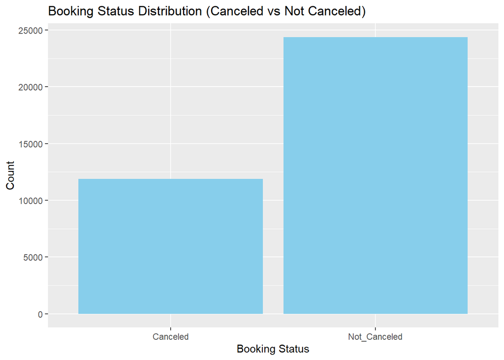

```r
print(ggplot(data, aes(x = booking_status)) +
  geom_bar(fill = "skyblue") +
  labs(title = "Booking Status Distribution (Canceled vs Not Canceled)",
       x = "Booking Status", y = "Count"))
```

## Box plot for Lead Time vs Cancellations:

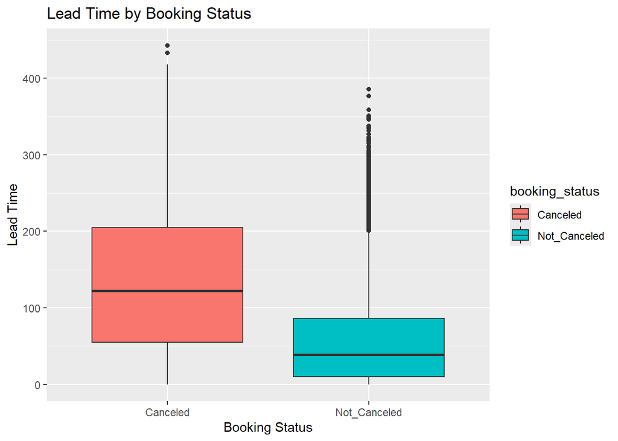

```r
# Box plot for lead time vs. cancellations
print(ggplot(data, aes(x = booking_status, y = lead_time, fill = booking_status)) +
  geom_boxplot() +
  labs(title = "Lead Time by Booking Status", x = "Booking Status", y = "Lead Time"))
```

## Average Price per Room vs Cancellations

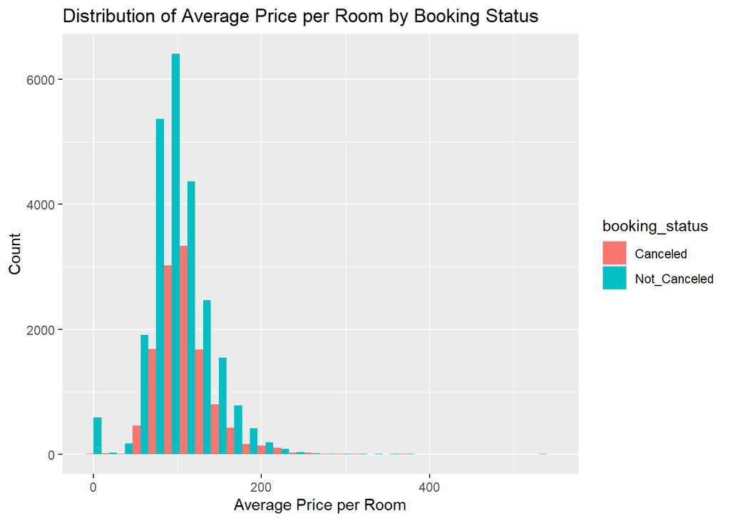

```r
# Histogram for average price per room by booking status
print(ggplot(data, aes(x = avg_price_per_room, fill = booking_status)) +
  geom_histogram(bins = 30, position = "dodge") +
  labs(title = "Distribution of Average Price per Room by Booking Status",
       x = "Average Price per Room", y = "Count"))
```

## Special Requests vs Cancellations

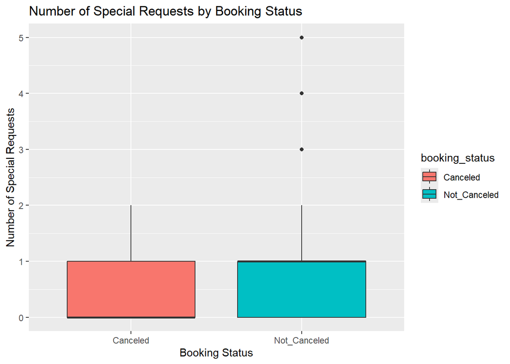

```r
# Box plot for number of special requests vs. booking status
print(ggplot(data, aes(x = booking_status, y = no_of_special_requests, fill = booking_status)) +
  geom_boxplot() +
  labs(title = "Number of Special Requests by Booking Status",
       x = "Booking Status", y = "Number of Special Requests"))
```

```r
data <- data[ , !(names(data) %in% c("Booking_ID"))]
head(data)
```

```
##   no_of_adults no_of_children no_of_weekend_nights no_of_week_nights
## 1            2              0                    1                 2
## 2            2              0                    2                 3
## 3            1              0                    2                 1
## 4            2              0                    0                 2
## 5            2              0                    1                 1
## 6            2              0                    0                 2
##   type_of_meal_plan required_car_parking_space room_type_reserved lead_time
## 1       Meal Plan 1                          0        Room_Type 1       224
## 2      Not Selected                          0        Room_Type 1         5
## 3       Meal Plan 1                          0        Room_Type 1         1
## 4       Meal Plan 1                          0        Room_Type 1       211
## 5      Not Selected                          0        Room_Type 1        48
## 6       Meal Plan 2                          0        Room_Type 1       346
##   arrival_year arrival_month arrival_date market_segment_type repeated_guest
```

[output cut: 20 more lines]

## Seasonality Analysis:

```r
# Define seasons based on arrival month
data$season <- case_when(
  data$arrival_month %in% c(3, 4, 5) ~ "Spring",
  data$arrival_month %in% c(6, 7, 8) ~ "Summer",
  data$arrival_month %in% c(9, 10, 11) ~ "Fall",
  data$arrival_month %in% c(12, 1, 2) ~ "Winter",
  TRUE ~ "Unknown"
)
# Convert booking_status to a binary variable
data$booking_status_binary <- ifelse(data$booking_status == "Canceled", 1, 0)
```

### Creating subsets for each season:

```r
# Create subsets for each season
spring_data <- subset(data, season == "Spring")
summer_data <- subset(data, season == "Summer")
fall_data <- subset(data, season == "Fall")
winter_data <- subset(data, season == "Winter")
```

### Remove columns with zero variance

```r
# Function to remove columns with zero variance
remove_zero_variance <- function(df) {
  df[, sapply(df, function(col) sd(col, na.rm = TRUE) != 0)]
}

# Remove zero variance columns for each season
spring_data_filtered <- remove_zero_variance(select_if(spring_data, is.numeric))
summer_data_filtered <- remove_zero_variance(select_if(summer_data, is.numeric))
fall_data_filtered <- remove_zero_variance(select_if(fall_data, is.numeric))
winter_data_filtered <- remove_zero_variance(select_if(winter_data, is.numeric))
```

### Calculate correlation matrices:

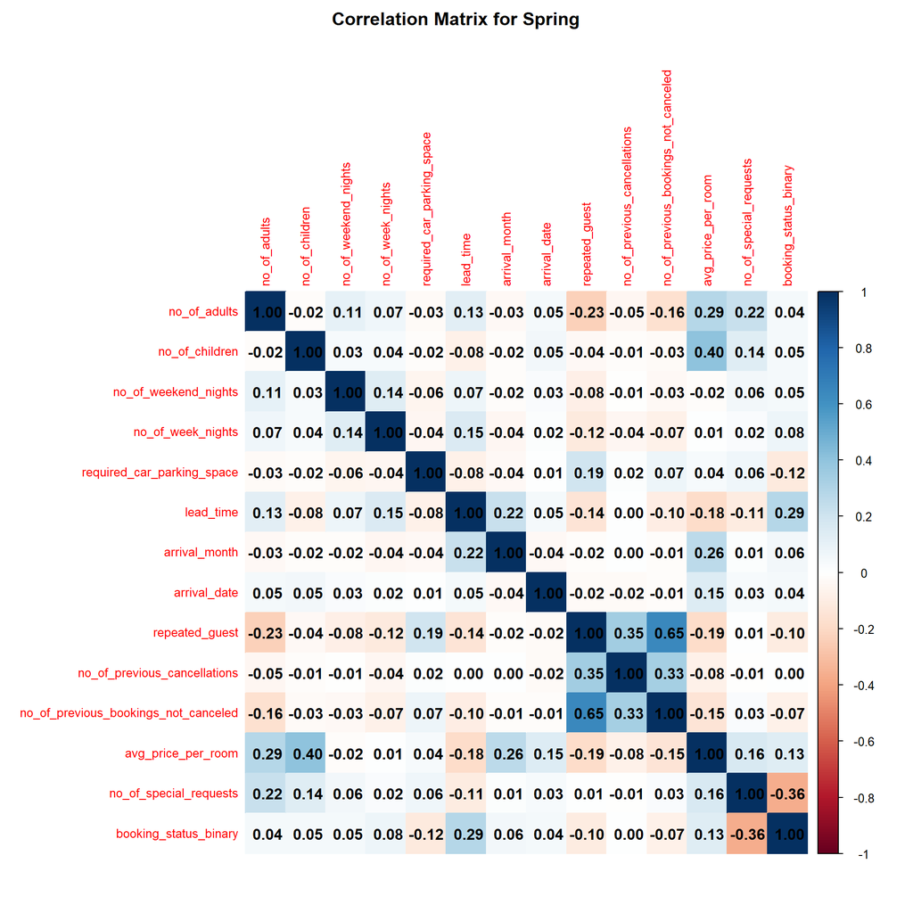

```r
# Calculate and visualize correlation for Spring
cor_spring <- cor(spring_data_filtered, use = "complete.obs")
corrplot(cor_spring, method = "color", addCoef.col = "black",
         title = "Correlation Matrix for Spring", number.cex = 1,
         tl.cex = 0.8, mar = c(1, 1, 2, 1))
```

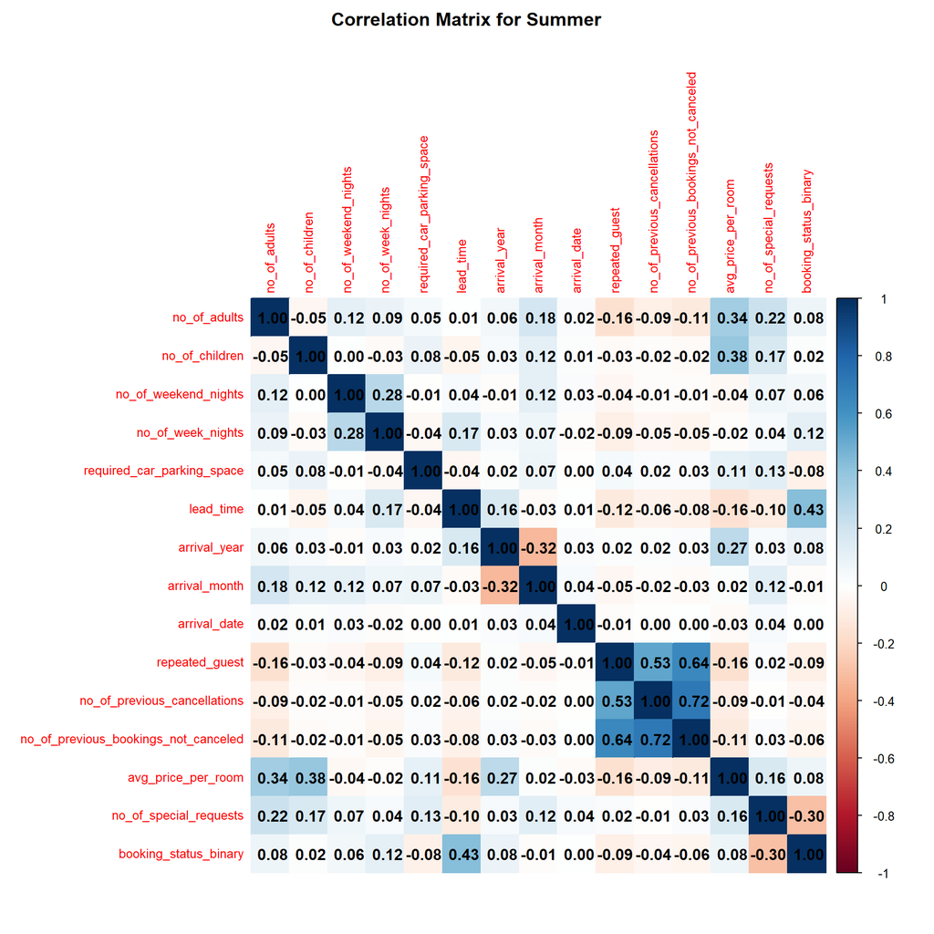

```r
# Calculate and visualize correlation for Summer
cor_summer <- cor(summer_data_filtered, use = "complete.obs")
corrplot(cor_summer, method = "color", addCoef.col = "black",
         title = "Correlation Matrix for Summer", number.cex = 1,
         tl.cex = 0.8, mar = c(1, 1, 2, 1))
```

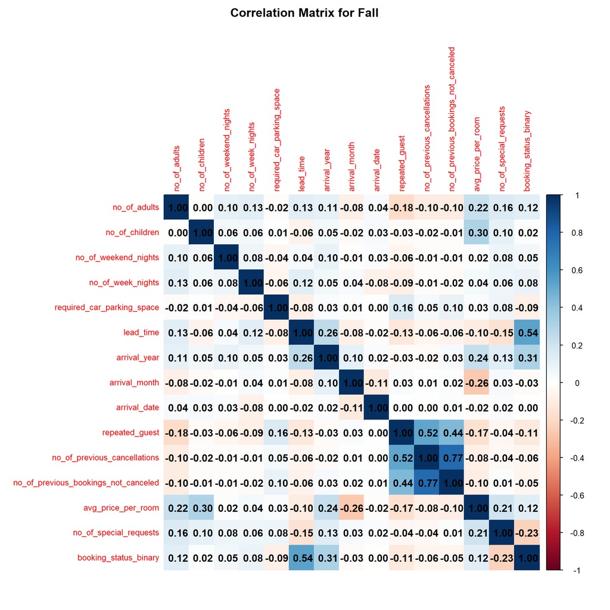

```r
# Calculate and visualize correlation for Fall
cor_fall <- cor(fall_data_filtered, use = "complete.obs")
corrplot(cor_fall, method = "color", addCoef.col = "black",
         title = "Correlation Matrix for Fall", number.cex = 1,
         tl.cex = 0.8, mar = c(1, 1, 2, 1))
```

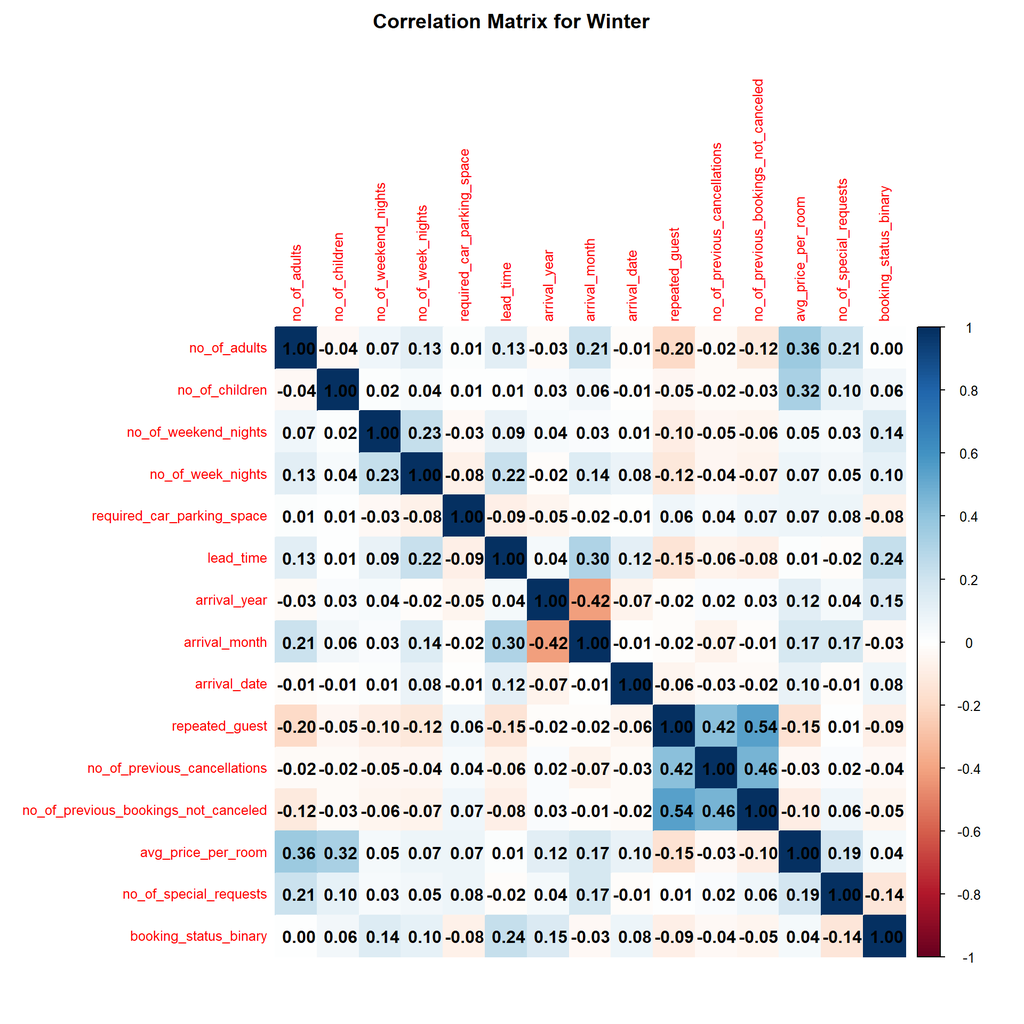

```r
# Calculate and visualize correlation for Winter
cor_winter <- cor(winter_data_filtered, use = "complete.obs")
corrplot(cor_winter, method = "color", addCoef.col = "black",
         title = "Correlation Matrix for Winter", number.cex = 1,
         tl.cex = 0.8, mar = c(1, 1, 2, 1))
```